[figure not shown]

[figure not shown]

# WATER QUALITY ANALYSIS

[figure not shown]

# INTRODUCTION

#### Access to safe drinking-water is essential to health, a basic human right and a component of effective policy for health protection. This is important as a health and development issue at a national, regional and local level. In some regions, it has been shown that investments in water supply and sanitation can yield a net economic benefit, since the reductions in adverse health effects and health care costs outweigh the costs of undertaking the interventions.

### HARDWARE AND SOFTWARE REQUIREMENT:-

#### HARDWARE:-

#### Processor- Intel® Core™ i5 11th gen

#### Graphic card- NVIDIA® GeForce® GTX 1650

#### RAM- 8 GB, DDR4.

#### -Hardisk-512 GB SSD

#### SOFTWARE

#### - Jupyter Notebook

#### - Python

#### Libraries like:-

#### - matplot

#### - seaborn

#### - pandas

#### - numpy

```python
import numpy as np # linear algebra
import matplotlib.pyplot as plt # library for data visualization contains- graphs, charts etc
import pandas as pd # data processing, CSV file I/O (e.g. pd.read_csv)
import seaborn as sns # like matplot, less complex and more features
```

```python
data = pd.read_csv("water_potability.csv") # read the csv data
```

```python
data.head() #print the first five elements from the data set
```

|  | ph | Hardness | Solids | Chloramines | Sulfate | Conductivity | Organic_carbon | Trihalomethanes | Turbidity | Potability |
| --- | --- | --- | --- | --- | --- | --- | --- | --- | --- | --- |
| 0 | NaN | 204.890455 | 20791.318981 | 7.300212 | 368.516441 | 564.308654 | 10.379783 | 86.990970 | 2.963135 | 0 |
| 1 | 3.716080 | 129.422921 | 18630.057858 | 6.635246 | NaN | 592.885359 | 15.180013 | 56.329076 | 4.500656 | 0 |
| 2 | 8.099124 | 224.236259 | 19909.541732 | 9.275884 | NaN | 418.606213 | 16.868637 | 66.420093 | 3.055934 | 0 |
| 3 | 8.316766 | 214.373394 | 22018.417441 | 8.059332 | 356.886136 | 363.266516 | 18.436524 | 100.341674 | 4.628771 | 0 |
| 4 | 9.092223 | 181.101509 | 17978.986339 | 6.546600 | 310.135738 | 398.410813 | 11.558279 | 31.997993 | 4.075075 | 0 |

```python
data.tail() #print the last five elements from the data set
```

|  | ph | Hardness | Solids | Chloramines | Sulfate | Conductivity | Organic_carbon | Trihalomethanes | Turbidity | Potability |
| --- | --- | --- | --- | --- | --- | --- | --- | --- | --- | --- |
| 3271 | 4.668102 | 193.681735 | 47580.991603 | 7.166639 | 359.948574 | 526.424171 | 13.894419 | 66.687695 | 4.435821 | 1 |
| 3272 | 7.808856 | 193.553212 | 17329.802160 | 8.061362 | NaN | 392.449580 | 19.903225 | NaN | 2.798243 | 1 |
| 3273 | 9.419510 | 175.762646 | 33155.578218 | 7.350233 | NaN | 432.044783 | 11.039070 | 69.845400 | 3.298875 | 1 |
| 3274 | 5.126763 | 230.603758 | 11983.869376 | 6.303357 | NaN | 402.883113 | 11.168946 | 77.488213 | 4.708658 | 1 |
| 3275 | 7.874671 | 195.102299 | 17404.177061 | 7.509306 | NaN | 327.459760 | 16.140368 | 78.698446 | 2.309149 | 1 |

## MOTIVATION

Water pollution can have some tremendously-adverse effect on the health of any and every life form living in the vicinity of the polluted water body or using water that has been polluted to some extent. At a certain level polluted water can be detrimental to crops and reduce the fertility of soil thus harming the overall agricultural sector and the country as well. When sea water is polluted it can also impact oceanic life in a bad way. The most fundamental effect of water pollution is however on the quality of the water, consuming which can lead to several ailments. In the urban areas water is used for both industrial and domestic purposes from waterbodies such as rivers, lakes, streams, wells, and ponds. Worst still, 80% of the water that we use for our domestic purposes is passed out in the form of wastewater. In most of the cases, this water is not treated properly and as such it leads to tremendous pollution of surface-level freshwater.In fact as far as India is concerned polluted water is one of the major factors behind the general low levels of health in India, especially in the rural areas. Polluted water can lead to diseases such as cholera, tuberculosis, dysentery, jaundice, diarrhoea, etc. In fact, around 80% stomach ailments in India happen because of consuming polluted water.

## OBJECTIVE

#### 2. Hardness:

Hardness is mainly caused by calcium and magnesium salts. These salts are dissolved from geologic deposits through which water travels. The length of time water is in contact with hardness producing material helps determine how much hardness there is in raw water. Hardness was originally defined as the capacity of water to precipitate soap caused by Calcium and Magnesium.

#### 3. Solids (Total dissolved solids - TDS)

Water has the ability to dissolve a wide range of inorganic and some organic minerals or salts such as potassium, calcium, sodium, bicarbonates, chlorides, magnesium, sulfates etc. These minerals produced un-wanted taste and diluted color in appearance of water. This is the important parameter for the use of water. The water with high TDS value indicates that water is highly mineralized. Desirable limit for TDS is 500 mg/l and maximum limit is 1000 mg/l which prescribed for drinking purpose.

#### 4. Chloramines:

Chlorine and chloramine are the major disinfectants used in public water systems. Chloramines are most commonly formed when ammonia is added to chlorine to treat drinking water. Chlorine levels up to 4 milligrams per liter (mg/L or 4 parts per million (ppm)) are considered safe in drinking water.

#### 5. Sulfate:

Sulfates are naturally occurring substances that are found in minerals, soil, and rocks. They are present in ambient air, groundwater, plants, and food. The principal commercial use of sulfate is in the chemical industry. Sulfate concentration in seawater is about 2,700 milligrams per liter (mg/L). It ranges from 3 to 30 mg/L in most freshwater supplies, although much higher concentrations (1000 mg/L) are found in some geographic locations.

#### 6. Conductivity:

Pure water is not a good conductor of electric current rather’s a good insulator. Increase in ions concentration enhances the electrical conductivity of water. Generally, the amount of dissolved solids in water determines the electrical conductivity. Electrical conductivity (EC) actually measures the ionic process of a solution that enables it to transmit current. According to WHO standards, EC value should not exceeded 400 μS/cm.

#### 7. Organic_carbon:

Total Organic Carbon (TOC) in source waters comes from decaying natural organic matter (NOM) as well as synthetic sources. TOC is a measure of the total amount of carbon in organic compounds in pure water. According to US EPA < 2 mg/L as TOC in treated / drinking water, and < 4 mg/Lit in source water which is use for treatment.

#### 8. Trihalomethanes:

THMs are chemicals which may be found in water treated with chlorine. The concentration of THMs in drinking water varies according to the level of organic material in the water, the amount of chlorine required to treat the water, and the temperature of the water that is being treated. THM levels up to 80 ppm is considered safe in drinking water.

#### 10. Potability:

Indicates if water is safe for human consumption where 1 means Potable and 0 means Not potable.

```python
data.isnull() #print all the null values
```

|  | ph | Hardness | Solids | Chloramines | Sulfate | Conductivity | Organic_carbon | Trihalomethanes | Turbidity | Potability |
| --- | --- | --- | --- | --- | --- | --- | --- | --- | --- | --- |
| 0 | True | False | False | False | False | False | False | False | False | False |
| 1 | False | False | False | False | True | False | False | False | False | False |
| 2 | False | False | False | False | True | False | False | False | False | False |
| 3 | False | False | False | False | False | False | False | False | False | False |
| 4 | False | False | False | False | False | False | False | False | False | False |
| ... | ... | ... | ... | ... | ... | ... | ... | ... | ... | ... |
| 3271 | False | False | False | False | False | False | False | False | False | False |
| 3272 | False | False | False | False | True | False | False | True | False | False |
| 3273 | False | False | False | False | True | False | False | False | False | False |
| 3274 | False | False | False | False | True | False | False | False | False | False |
| 3275 | False | False | False | False | True | False | False | False | False | False |

3276 rows × 10 columns

```python
data.isnull().sum()  #total sum of all the values
```

```
ph                 491
Hardness             0
Solids               0
Chloramines          0
Sulfate            781
Conductivity         0
Organic_carbon       0
Trihalomethanes    162
Turbidity            0
Potability           0
dtype: int64
```

```python
data.shape #total number of rows and columns
```

```
(3276, 10)
```

```python
data['ph'] #shows all data the from the ph column
```

```
0            NaN
1       3.716080
2       8.099124
3       8.316766
4       9.092223
          ...
3271    4.668102
3272    7.808856
3273    9.419510
3274    5.126763
3275    7.874671
Name: ph, Length: 3276, dtype: float64
```

```python
data['ph'].mean() #mean of all the values
```

```
7.080794504276819
```

## MEAN

A mean is the simple mathematical average of a set of two or more numbers. The mean for a given set of numbers can be computed in more than one way, including the arithmetic mean method, which uses the sum of the numbers in the series, and the geometric mean method, which is the average of a set of product

```python
data['ph'].fillna(data['ph'].mean(), inplace=True) #We fill the empty cells with the mean of all data
```

```python
data.isnull()
```

|  | ph | Hardness | Solids | Chloramines | Sulfate | Conductivity | Organic_carbon | Trihalomethanes | Turbidity | Potability |
| --- | --- | --- | --- | --- | --- | --- | --- | --- | --- | --- |
| 0 | False | False | False | False | False | False | False | False | False | False |
| 1 | False | False | False | False | True | False | False | False | False | False |
| 2 | False | False | False | False | True | False | False | False | False | False |
| 3 | False | False | False | False | False | False | False | False | False | False |
| 4 | False | False | False | False | False | False | False | False | False | False |
| ... | ... | ... | ... | ... | ... | ... | ... | ... | ... | ... |
| 3271 | False | False | False | False | False | False | False | False | False | False |
| 3272 | False | False | False | False | True | False | False | True | False | False |
| 3273 | False | False | False | False | True | False | False | False | False | False |
| 3274 | False | False | False | False | True | False | False | False | False | False |
| 3275 | False | False | False | False | True | False | False | False | False | False |

3276 rows × 10 columns

## This helps to show sum of cells with null the data

```python
data.isnull().sum()
```

```
ph                   0
Hardness             0
Solids               0
Chloramines          0
Sulfate            781
Conductivity         0
Organic_carbon       0
Trihalomethanes    162
Turbidity            0
Potability           0
dtype: int64
```

#### Same process is followed for the other columns as well.

```python
data['Sulfate'].mean()
```

```
333.7757766108134
```

```python
data['Sulfate'].fillna(data['Sulfate'].mean(),inplace= True)
```

```python
data['Sulfate'].isnull()
```

```
0       False
1       False
2       False
3       False
4       False
        ...
3271    False
3272    False
3273    False
3274    False
3275    False
Name: Sulfate, Length: 3276, dtype: bool
```

```python
data.isnull().sum()
```

```
ph                   0
Hardness             0
Solids               0
Chloramines          0
Sulfate              0
Conductivity         0
Organic_carbon       0
Trihalomethanes    162
Turbidity            0
Potability           0
dtype: int64
```

```python
data['Trihalomethanes'].fillna(data['Trihalomethanes'].mean(), inplace=True)
```

```python
data.isnull().sum()
```

```
ph                 0
Hardness           0
Solids             0
Chloramines        0
Sulfate            0
Conductivity       0
Organic_carbon     0
Trihalomethanes    0
Turbidity          0
Potability         0
dtype: int64
```

### This shows data type and description of data

```python
data.info()
```

```
<class 'pandas.core.frame.DataFrame'>
RangeIndex: 3276 entries, 0 to 3275
Data columns (total 10 columns):
 #   Column           Non-Null Count  Dtype
---  ------           --------------  -----
 0   ph               3276 non-null   float64
 1   Hardness         3276 non-null   float64
 2   Solids           3276 non-null   float64
 3   Chloramines      3276 non-null   float64
 4   Sulfate          3276 non-null   float64
 5   Conductivity     3276 non-null   float64
 6   Organic_carbon   3276 non-null   float64
 7   Trihalomethanes  3276 non-null   float64
 8   Turbidity        3276 non-null   float64
 9   Potability       3276 non-null   int64
dtypes: float64(9), int64(1)
memory usage: 256.1 KB
```

```python
data.info()
```

```
<class 'pandas.core.frame.DataFrame'>
RangeIndex: 3276 entries, 0 to 3275
Data columns (total 10 columns):
 #   Column           Non-Null Count  Dtype
---  ------           --------------  -----
 0   ph               3276 non-null   float64
 1   Hardness         3276 non-null   float64
 2   Solids           3276 non-null   float64
 3   Chloramines      3276 non-null   float64
 4   Sulfate          3276 non-null   float64
 5   Conductivity     3276 non-null   float64
 6   Organic_carbon   3276 non-null   float64
 7   Trihalomethanes  3276 non-null   float64
 8   Turbidity        3276 non-null   float64
 9   Potability       3276 non-null   int64
dtypes: float64(9), int64(1)
memory usage: 256.1 KB
```

```python
data.describe()
```

|  | ph | Hardness | Solids | Chloramines | Sulfate | Conductivity | Organic_carbon | Trihalomethanes | Turbidity | Potability |
| --- | --- | --- | --- | --- | --- | --- | --- | --- | --- | --- |
| count | 3276.000000 | 3276.000000 | 3276.000000 | 3276.000000 | 3276.000000 | 3276.000000 | 3276.000000 | 3276.000000 | 3276.000000 | 3276.000000 |
| mean | 7.080795 | 196.369496 | 22014.092526 | 7.122277 | 333.775777 | 426.205111 | 14.284970 | 66.396293 | 3.966786 | 0.390110 |
| std | 1.469956 | 32.879761 | 8768.570828 | 1.583085 | 36.142612 | 80.824064 | 3.308162 | 15.769881 | 0.780382 | 0.487849 |
| min | 0.000000 | 47.432000 | 320.942611 | 0.352000 | 129.000000 | 181.483754 | 2.200000 | 0.738000 | 1.450000 | 0.000000 |
| 25% | 6.277673 | 176.850538 | 15666.690297 | 6.127421 | 317.094638 | 365.734414 | 12.065801 | 56.647656 | 3.439711 | 0.000000 |
| 50% | 7.080795 | 196.967627 | 20927.833607 | 7.130299 | 333.775777 | 421.884968 | 14.218338 | 66.396293 | 3.955028 | 0.000000 |
| 75% | 7.870050 | 216.667456 | 27332.762127 | 8.114887 | 350.385756 | 481.792304 | 16.557652 | 76.666609 | 4.500320 | 1.000000 |
| max | 14.000000 | 323.124000 | 61227.196008 | 13.127000 | 481.030642 | 753.342620 | 28.300000 | 124.000000 | 6.739000 | 1.000000 |

# EDA (exploratory data analysis)

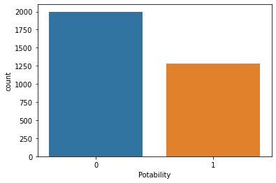

```python
sns.countplot(x="Potability",data=data)
```

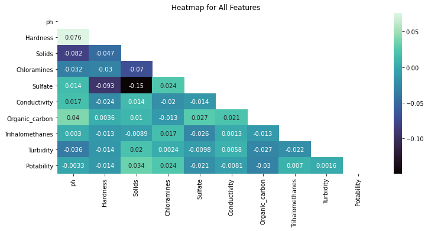

```python
plt.figure(figsize=(12, 5))
mask = np.triu(np.ones_like(data.corr(), dtype= bool))
sns.heatmap(data.corr(), mask=mask,annot=True,cmap='mako')
plt.title('Heatmap for All Features');
```

##### See the correlation of all the feature variables with the target variable

```python
data['Potability'].value_counts()
```

```
0    1998
1    1278
Name: Potability, dtype: int64
```

#### This will help to count the number of potable and non potable water

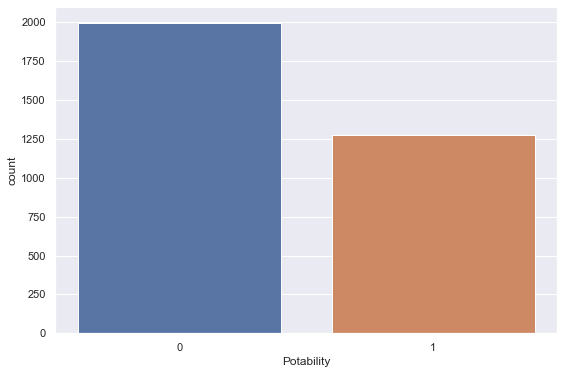

```python
plt.figure(figsize=(9,6))
sns.set_theme(style="darkgrid")
sns.countplot(x="Potability", data=data)#countplot is barplot for seaborn
plt.plot();
```

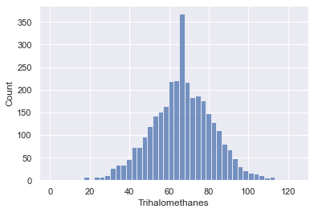

```python
sns.histplot(data=data, x='Trihalomethanes')
```

## SUBPLOTS

### These are used to plot graphs for individual columns seperately

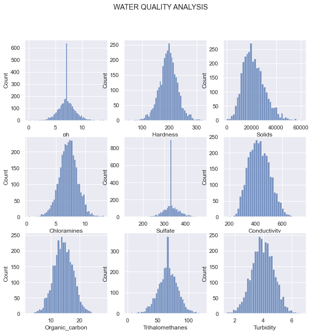

```python
fig, axes = plt.subplots(3,3, figsize=(10,10))
fig.suptitle("WATER QUALITY ANALYSIS")
sns.histplot(ax= axes[0,0], data=data , x='ph')
sns.histplot(ax= axes[0,1], data=data , x='Hardness')
sns.histplot(ax= axes[0,2], data=data , x='Solids')
sns.histplot(ax= axes[1,0], data=data , x='Chloramines')
sns.histplot(ax= axes[1,1], data=data , x='Sulfate')
sns.histplot(ax= axes[1,2], data=data , x='Conductivity')
sns.histplot(ax= axes[2,0], data=data , x='Organic_carbon')
sns.histplot(ax= axes[2,1], data=data , x='Trihalomethanes')
sns.histplot(ax= axes[2,2], data=data , x='Turbidity');
```

```python
non_potable = data[data["Potability"]== 0] #we are assigning variable data with potability 0
potable = data[data["Potability"] == 1]#we are assigning the variable data with potability 1
non_potable
```

|  | ph | Hardness | Solids | Chloramines | Sulfate | Conductivity | Organic_carbon | Trihalomethanes | Turbidity | Potability |
| --- | --- | --- | --- | --- | --- | --- | --- | --- | --- | --- |
| 0 | 7.080795 | 204.890455 | 20791.318981 | 7.300212 | 368.516441 | 564.308654 | 10.379783 | 86.990970 | 2.963135 | 0 |
| 1 | 3.716080 | 129.422921 | 18630.057858 | 6.635246 | 333.775777 | 592.885359 | 15.180013 | 56.329076 | 4.500656 | 0 |
| 2 | 8.099124 | 224.236259 | 19909.541732 | 9.275884 | 333.775777 | 418.606213 | 16.868637 | 66.420093 | 3.055934 | 0 |
| 3 | 8.316766 | 214.373394 | 22018.417441 | 8.059332 | 356.886136 | 363.266516 | 18.436524 | 100.341674 | 4.628771 | 0 |
| 4 | 9.092223 | 181.101509 | 17978.986339 | 6.546600 | 310.135738 | 398.410813 | 11.558279 | 31.997993 | 4.075075 | 0 |
| ... | ... | ... | ... | ... | ... | ... | ... | ... | ... | ... |
| 3112 | 6.616731 | 195.096968 | 34277.760400 | 7.632639 | 333.775777 | 417.465080 | 13.432557 | 47.945936 | 3.622379 | 0 |
| 3113 | 7.734569 | 230.919506 | 21776.594455 | 6.908591 | 333.775777 | 395.114961 | 15.033557 | 92.697369 | 3.821456 | 0 |
| 3114 | 6.971577 | 185.906938 | 27959.987873 | 7.214510 | 349.743879 | 414.067354 | 19.882917 | 36.179003 | 3.226349 | 0 |
| 3115 | 4.709187 | 179.141018 | 22291.418577 | 6.774276 | 407.417977 | 371.264843 | 18.186801 | 86.528627 | 3.860084 | 0 |
| 3116 | 5.230003 | 176.714023 | 27971.891806 | 7.597981 | 413.914001 | 440.355374 | 14.423614 | 72.837370 | 3.045612 | 0 |

1998 rows × 10 columns

### this is the mean of all paramneters with potability 0

```python
agg_non_potable = non_potable.mean()
agg_non_potable
```

```
ph                     7.084658
Hardness             196.733292
Solids             21777.490788
Chloramines            7.092175
Sulfate              334.371700
Conductivity         426.730454
Organic_carbon        14.364335
Trihalomethanes       66.308522
Turbidity              3.965800
Potability             0.000000
dtype: float64
```

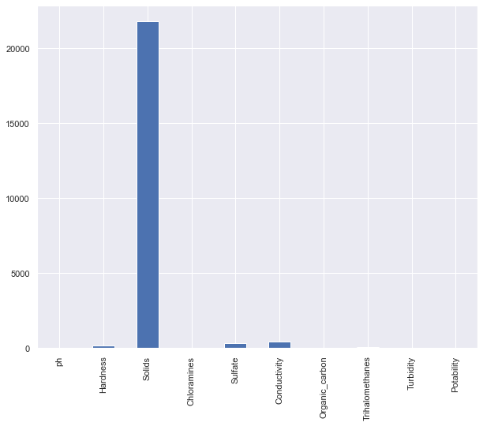

```python
plt.figure(figsize=(10,8))
agg_non_potable.plot(kind='bar')
```

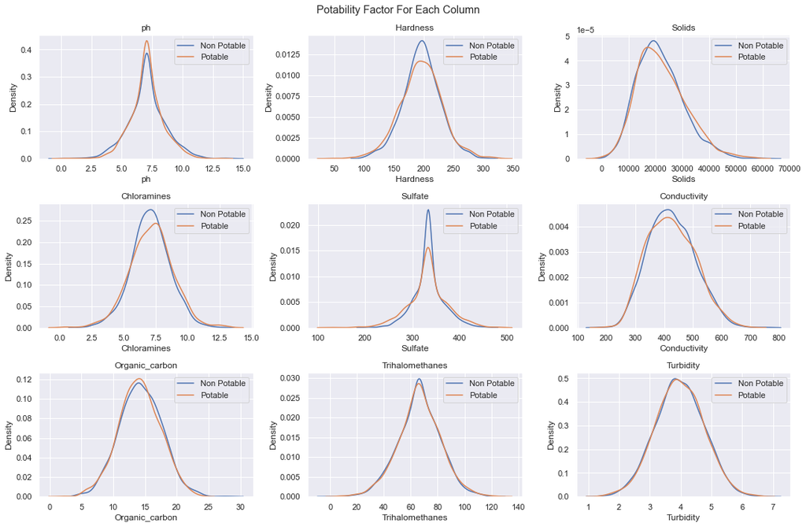

```python
plt.figure(figsize=(15,10))
for ax, col in enumerate(data.columns[:9]):
    plt.subplot(3,3, ax+1)
    plt.suptitle("Potability Factor For Each Column")
    plt.title(col)
    sns.kdeplot(x=non_potable[col], label= "Non Potable")
    sns.kdeplot(x=potable[col], label="Potable")
    plt.legend()
plt.tight_layout()
```

### This plot shows how the various factors effects the density of water

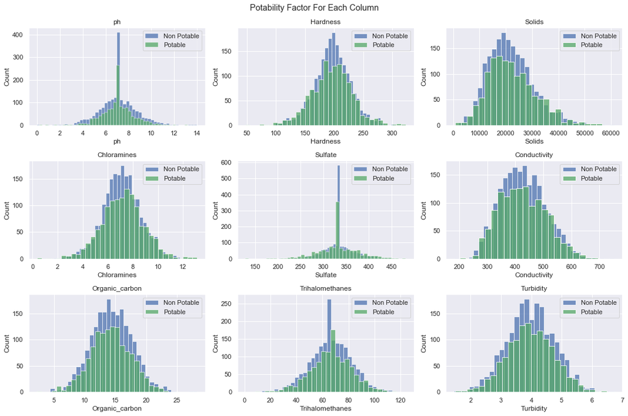

```python
plt.figure(figsize=(15,10))
for ax, col in enumerate(data.columns[:9]):
    plt.subplot(3,3, ax+1)
    plt.suptitle("Potability Factor For Each Column")
    plt.title(col)
    sns.histplot(x=non_potable[col], label= "Non Potable")
    sns.histplot(x=potable[col], label="Potable",color="g")
    plt.legend()
plt.tight_layout()
```

### Factors effecting the potability of water

```python
data["Hardness"]
```

```
0       204.890455
1       129.422921
2       224.236259
3       214.373394
4       181.101509
           ...
3271    193.681735
3272    193.553212
3273    175.762646
3274    230.603758
3275    195.102299
Name: Hardness, Length: 3276, dtype: float64
```

#### This functions helps to determine hardness of water and catergories it into soft, slightly hard, moderately hard, hard, very hard

```python
def hardeness(x):
    if x<17.1:
        x="Soft"
    elif 17.1<x<60:
        x="Slightly Hard"
    elif 60 <x <120:
        x="Moderately Hard"
    elif 120 <x <180:
        x="Hard"
    elif x > 180:
        x="Very Hard"
    return x
```

#### This functions helps to determine nature of water by calculating its pH

```python
def phs(x):
    if (x > 9):
        x = "Alkaline water"
    elif (x <= 9 and x > 8):
        x = "Bottled waters labeled as alkaline"
    elif (x <= 8 and x > 7.5 ):
        x = "Ocean water"
    elif(x == 7.5 ):
        x = "Tap water"
    elif(x < 7.5 and x >=6.5):
        x = "Water Bottles"
    elif(x < 6.5 and x >=5.5):
        x = "Distilled osmosis water"
    else:
        x = "Acidic water"
    return x
```

```python
data["ph_Scale"] = data["ph"].apply(phs)
```

```python
data["Hard"] = data["Hardness"].apply(hardeness)
```

```python
data["Hard"].value_counts() #general count of amount of water samples that are categorised
```

```
Very Hard          2341
Hard                883
Moderately Hard      51
Slightly Hard         1
Name: Hard, dtype: int64
```

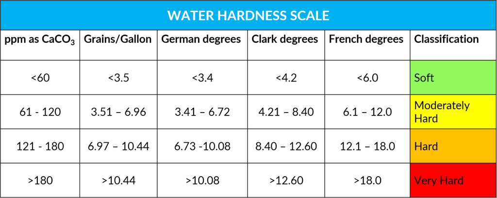

```python
data["ph_Scale"].value_counts() #general count of amount of water samples that are categorised
```

```
Water Bottles                         1249
Distilled osmosis water                554
Bottled waters labeled as alkaline     424
Acidic water                           414
Ocean water                            328
Alkaline water                         307
Name: ph_Scale, dtype: int64
```

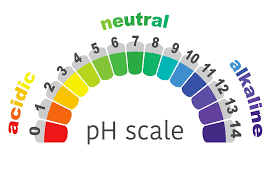

```python
data
```

|  | ph | Hardness | Solids | Chloramines | Sulfate | Conductivity | Organic_carbon | Trihalomethanes | Turbidity | Potability | ph_Scale | Hard |
| --- | --- | --- | --- | --- | --- | --- | --- | --- | --- | --- | --- | --- |
| 0 | 7.080795 | 204.890455 | 20791.318981 | 7.300212 | 368.516441 | 564.308654 | 10.379783 | 86.990970 | 2.963135 | 0 | Water Bottles | Very Hard |
| 1 | 3.716080 | 129.422921 | 18630.057858 | 6.635246 | 333.775777 | 592.885359 | 15.180013 | 56.329076 | 4.500656 | 0 | Acidic water | Hard |
| 2 | 8.099124 | 224.236259 | 19909.541732 | 9.275884 | 333.775777 | 418.606213 | 16.868637 | 66.420093 | 3.055934 | 0 | Bottled waters labeled as alkaline | Very Hard |
| 3 | 8.316766 | 214.373394 | 22018.417441 | 8.059332 | 356.886136 | 363.266516 | 18.436524 | 100.341674 | 4.628771 | 0 | Bottled waters labeled as alkaline | Very Hard |
| 4 | 9.092223 | 181.101509 | 17978.986339 | 6.546600 | 310.135738 | 398.410813 | 11.558279 | 31.997993 | 4.075075 | 0 | Alkaline water | Very Hard |
| ... | ... | ... | ... | ... | ... | ... | ... | ... | ... | ... | ... | ... |
| 3271 | 4.668102 | 193.681735 | 47580.991603 | 7.166639 | 359.948574 | 526.424171 | 13.894419 | 66.687695 | 4.435821 | 1 | Acidic water | Very Hard |
| 3272 | 7.808856 | 193.553212 | 17329.802160 | 8.061362 | 333.775777 | 392.449580 | 19.903225 | 66.396293 | 2.798243 | 1 | Ocean water | Very Hard |
| 3273 | 9.419510 | 175.762646 | 33155.578218 | 7.350233 | 333.775777 | 432.044783 | 11.039070 | 69.845400 | 3.298875 | 1 | Alkaline water | Hard |
| 3274 | 5.126763 | 230.603758 | 11983.869376 | 6.303357 | 333.775777 | 402.883113 | 11.168946 | 77.488213 | 4.708658 | 1 | Acidic water | Very Hard |
| 3275 | 7.874671 | 195.102299 | 17404.177061 | 7.509306 | 333.775777 | 327.459760 | 16.140368 | 78.698446 | 2.309149 | 1 | Ocean water | Very Hard |

3276 rows × 12 columns

```python
data = data[['ph','ph_Scale','Hardness','Hard','Solids','Chloramines','Sulfate','Conductivity','Organic_carbon','Trihalomethanes','Turbidity','Potability']]
```

```python
data
```

|  | ph | ph_Scale | Hardness | Hard | Solids | Chloramines | Sulfate | Conductivity | Organic_carbon | Trihalomethanes | Turbidity | Potability |
| --- | --- | --- | --- | --- | --- | --- | --- | --- | --- | --- | --- | --- |
| 0 | 7.080795 | Water Bottles | 204.890455 | Very Hard | 20791.318981 | 7.300212 | 368.516441 | 564.308654 | 10.379783 | 86.990970 | 2.963135 | 0 |
| 1 | 3.716080 | Acidic water | 129.422921 | Hard | 18630.057858 | 6.635246 | 333.775777 | 592.885359 | 15.180013 | 56.329076 | 4.500656 | 0 |
| 2 | 8.099124 | Bottled waters labeled as alkaline | 224.236259 | Very Hard | 19909.541732 | 9.275884 | 333.775777 | 418.606213 | 16.868637 | 66.420093 | 3.055934 | 0 |
| 3 | 8.316766 | Bottled waters labeled as alkaline | 214.373394 | Very Hard | 22018.417441 | 8.059332 | 356.886136 | 363.266516 | 18.436524 | 100.341674 | 4.628771 | 0 |
| 4 | 9.092223 | Alkaline water | 181.101509 | Very Hard | 17978.986339 | 6.546600 | 310.135738 | 398.410813 | 11.558279 | 31.997993 | 4.075075 | 0 |
| ... | ... | ... | ... | ... | ... | ... | ... | ... | ... | ... | ... | ... |
| 3271 | 4.668102 | Acidic water | 193.681735 | Very Hard | 47580.991603 | 7.166639 | 359.948574 | 526.424171 | 13.894419 | 66.687695 | 4.435821 | 1 |
| 3272 | 7.808856 | Ocean water | 193.553212 | Very Hard | 17329.802160 | 8.061362 | 333.775777 | 392.449580 | 19.903225 | 66.396293 | 2.798243 | 1 |
| 3273 | 9.419510 | Alkaline water | 175.762646 | Hard | 33155.578218 | 7.350233 | 333.775777 | 432.044783 | 11.039070 | 69.845400 | 3.298875 | 1 |
| 3274 | 5.126763 | Acidic water | 230.603758 | Very Hard | 11983.869376 | 6.303357 | 333.775777 | 402.883113 | 11.168946 | 77.488213 | 4.708658 | 1 |
| 3275 | 7.874671 | Ocean water | 195.102299 | Very Hard | 17404.177061 | 7.509306 | 333.775777 | 327.459760 | 16.140368 | 78.698446 | 2.309149 | 1 |

3276 rows × 12 columns

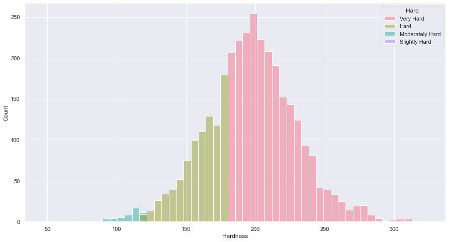

```python
plt.figure(figsize=(15,8))
sns.histplot(x="Hardness", hue="Hard", data=data, palette="husl");
```

#### Categorising water according to its hardness

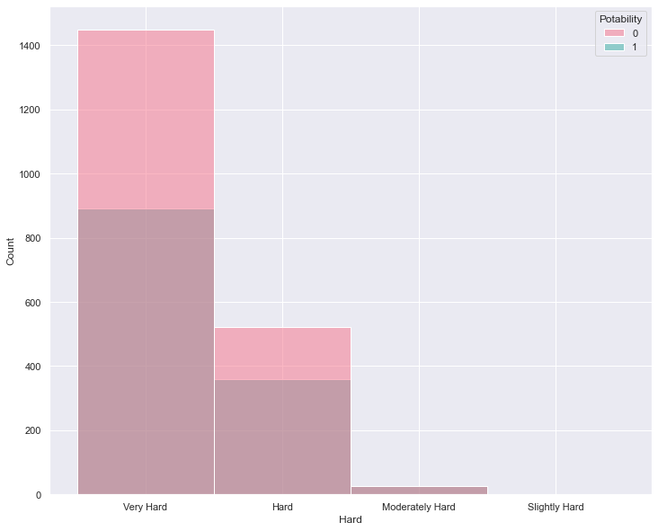

```python
plt.figure(figsize=(12,10))
sns.histplot(x="Hard",hue="Potability", data=data,palette="husl");
```

#### Potability of water according to its hardness

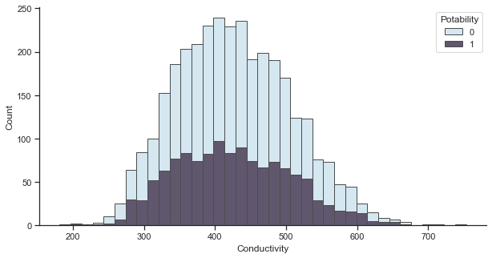

```python
sns.set_theme(style="ticks")
f, ax = plt.subplots(figsize=(10,5))
sns.despine(f)

sns.histplot(data,x="Conductivity", hue="Potability",multiple="stack",palette="ch:s=.25,rot=-.25",edgecolor=".3");
```

#### Graph determines the conductivity of water according to its potability

## CONCLUSION

#### After considering all the parameters and comparing the hardness and pH level of water we can finally represent the potability of water in the form of pie chart categorise the water in potable and non-potable form. As we can see that the percentage of non potable water is more than that potable which is alarming and we should be working on its conservation.

#### The best way to solve these issues is to prevent them. The first major solution in this context is conservation of soil. Soil erosion can contribute to water pollution. So, if soil can be conserved we can prevent water pollution too. We can follow measures such as planting more trees, managing erosion in a better way, and use farming methods that are better for the soil. In the same vein it is also important to follow the right methods in disposing toxic waste. For starters, we can use products that have lesser amounts of volatile organic compounds in them. Even in cases where toxic material like paints, cleaning supplies, and stain removers are used, they need to be disposed off in the right way. It is also important to look into oil leaks in one’s cars and machines.

#### It is said that leaked oil – even from cars and machines – is one of the principal contributors to water pollution. Hence, it is important to look at cars and machines, which run on oil, on a regular basis, to check them for any possible oil leak. It is important after work – especially in factories and production units where oil is used – to clean up the wasted oil and either dispose it properly or keep it for later use. Following are some other ways in which this problem can be addressed adequately:

#### -Cleaning up waterways and beaches

#### -Avoiding the usage of non-biodegradable material like plastic

#### -Being more involved in various measures pertaining to preventing water pollution.

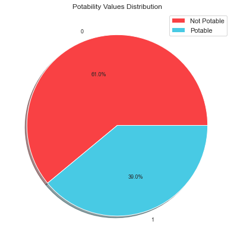

```python
colors=['#f94144', '#48cae4']
labels=['Not Potable','Potable']
pieplot = data.groupby('Potability').size()
pieplot.plot(kind='pie', colors=colors, subplots=True,shadow=True, figsize=(7, 7), fontsize=9, autopct='%1.1f%%')
plt.title("Potability Values Distribution")
plt.legend(labels)
plt.ylabel("")
```

#### Finally this graphs determine the amount of potable and non-potable water sample

### FUTURE WORK

#### With help of the data set that we have worked on we can further enhance this project by adding machine learning models which help us to determine the potability of water with help of trained datasets. By adding more columns to the data we can have other factors to decide the quality of water as well, which will make our analysis much more precise and informative.